# Regression

Elara

2016年5月4日

# 1 线性回归

## 1.1 线性模型

$$Y_i=e^{\beta_1+\beta_2X_i+\epsilon_i}$$
$$Y_i=\frac{1}{e^{\beta_1+\beta_2X_i+\epsilon_i}}$$
$$Y_i=\beta_1+(0.75-\beta_1)e^{-\beta_2(X_i-2)}+\epsilon_i$$
$$Y_i=\beta_1+\beta_2^{3}X_i+\epsilon_i$$
$$Y_i=\beta_1+\beta_2(\frac{1}{X_i})+\epsilon_i$$

1. 125是线性模型
2. 没有截距项的时候R2不能用。此时OLS的FOC没有$\beta_0$相关，得不到残差和=0
3. 无法把方差分解成可解释和不可解释部分。
4. 即使截距项不显著也不能去掉。去掉的话一定过原点。
5. R2受到模型变量数目影响。要用adj.R2

## 1.2 LM线性模型估计OLS

```r
#Y X 线性
options(digits=3)
fit <- lm(weight ~ height, data = women)
summary(fit)
```

```
##
## Call:
## lm(formula = weight ~ height, data = women)
##
## Residuals:
##    Min     1Q Median     3Q    Max
## -1.733 -1.133 -0.383  0.742  3.117
##
## Coefficients:
##             Estimate Std. Error t value Pr(>|t|)
## (Intercept) -87.5167     5.9369   -14.7  1.7e-09 ***
## height        3.4500     0.0911    37.9  1.1e-14 ***
## ---
## Signif. codes:  0 '***' 0.001 '**' 0.01 '*' 0.05 '.' 0.1 ' ' 1
##
## Residual standard error: 1.53 on 13 degrees of freedom
## Multiple R-squared:  0.991,  Adjusted R-squared:  0.99
## F-statistic: 1.43e+03 on 1 and 13 DF,  p-value: 1.09e-14
```

```r
coefficients(fit)
```

```
## (Intercept)      height
##      -87.52        3.45
```

```r
fitted(fit)
```

```
##   1   2   3   4   5   6   7   8   9  10  11  12  13  14  15
## 113 116 119 123 126 130 133 137 140 144 147 151 154 157 161
```

```r
residuals(fit)
```

```
##       1       2       3       4       5       6       7       8       9
##  2.4167  0.9667  0.5167  0.0667 -0.3833 -0.8333 -1.2833 -1.7333 -1.1833
##      10      11      12      13      14      15
## -1.6333 -1.0833 -0.5333  0.0167  1.5667  3.1167
```

```r
deviance(fit)
```

```
## [1] 30.2
```

```r
#置信区间0.99
confint(fit,level=0.99)
```

```
##               0.5 % 99.5 %
## (Intercept) -105.40 -69.63
## height         3.18   3.72
```

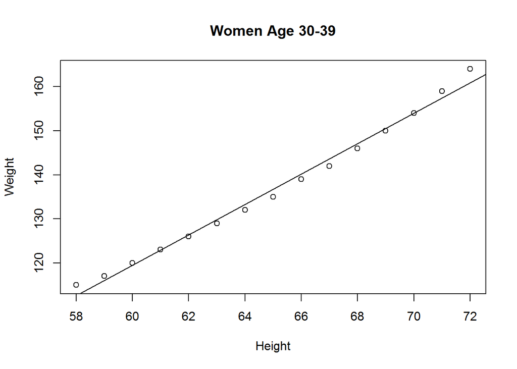

```r
plot(women$height,women$weight,main="Women Age 30-39",xlab="Height",ylab="Weight")

abline(fit)
```

```r
#x和y非线性
fit2 <- lm(weight ~ height + I(height^2), data=women)
summary(fit2)
```

```
##
## Call:
## lm(formula = weight ~ height + I(height^2), data = women)
##
## Residuals:
##     Min      1Q  Median      3Q     Max
## -0.5094 -0.2961 -0.0094  0.2862  0.5971
##
## Coefficients:
##              Estimate Std. Error t value Pr(>|t|)
## (Intercept) 261.87818   25.19677   10.39  2.4e-07 ***
## height       -7.34832    0.77769   -9.45  6.6e-07 ***
## I(height^2)   0.08306    0.00598   13.89  9.3e-09 ***
## ---
## Signif. codes:  0 '***' 0.001 '**' 0.01 '*' 0.05 '.' 0.1 ' ' 1
##
## Residual standard error: 0.384 on 12 degrees of freedom
## Multiple R-squared:  0.999,  Adjusted R-squared:  0.999
## F-statistic: 1.14e+04 on 2 and 12 DF,  p-value: <2e-16
```

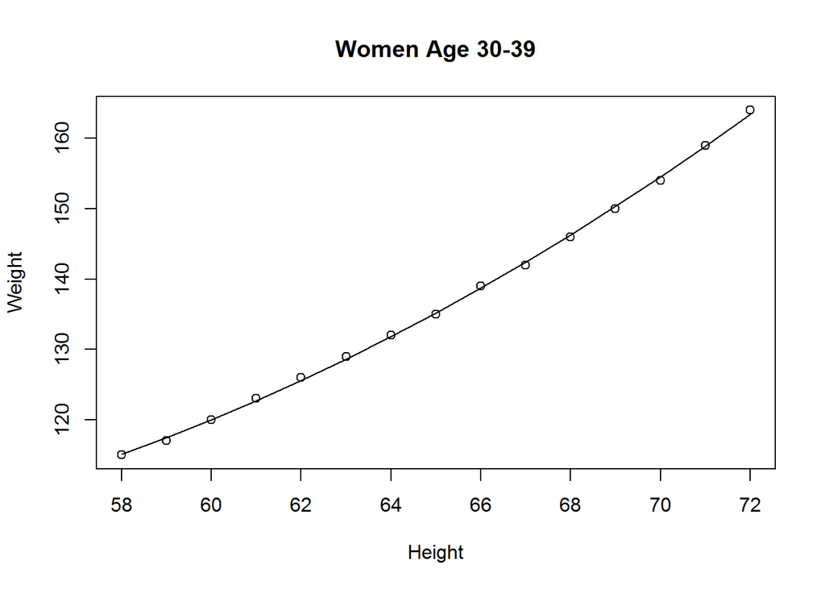

```r
plot(women$height, women$weight, main = "Women Age 30-39",
xlab = "Height", ylab = "Weight")
lines(women$height, fitted(fit2))
```

```r
Anscombe<-data.frame(
X =c(10.0, 8.0, 13.0, 9.0, 11.0, 14.0, 6.0, 4.0, 12.0, 7.0, 5.0),
Y1=c(8.04, 6.95, 7.58, 8.81, 8.33, 9.96, 7.24, 4.26, 10.84, 4.82, 5.68),
Y2=c(9.14, 8.14, 8.74, 8.77, 9.26, 8.10, 6.13, 3.10, 9.13, 7.26, 4.74),
Y3=c(7.46, 6.77, 12.74, 7.11, 7.81, 8.84, 6.08, 5.39, 8.15, 6.44, 5.73),
X4=c(rep(8,7), 19, rep(8,3)),
Y4=c(6.58, 5.76, 7.71, 8.84, 8.47, 7.04, 5.25, 12.50, 5.56, 7.91, 6.89)
)
summary(lm(Y1~X, data=Anscombe))
```

```
##
## Call:
## lm(formula = Y1 ~ X, data = Anscombe)
##
## Residuals:
##     Min      1Q  Median      3Q     Max
## -1.9213 -0.4558 -0.0414  0.7094  1.8388
##
## Coefficients:
##             Estimate Std. Error t value Pr(>|t|)
## (Intercept)    3.000      1.125    2.67   0.0257 *
## X              0.500      0.118    4.24   0.0022 **
## ---
## Signif. codes:  0 '***' 0.001 '**' 0.01 '*' 0.05 '.' 0.1 ' ' 1
##
## Residual standard error: 1.24 on 9 degrees of freedom
## Multiple R-squared:  0.667,  Adjusted R-squared:  0.629
## F-statistic:   18 on 1 and 9 DF,  p-value: 0.00217
```

```r
summary(lm(Y2~X, data=Anscombe))
```

```
##
## Call:
## lm(formula = Y2 ~ X, data = Anscombe)
##
## Residuals:
##    Min     1Q Median     3Q    Max
## -1.901 -0.761  0.129  0.949  1.269
##
## Coefficients:
##             Estimate Std. Error t value Pr(>|t|)
## (Intercept)    3.001      1.125    2.67   0.0258 *
## X              0.500      0.118    4.24   0.0022 **
## ---
## Signif. codes:  0 '***' 0.001 '**' 0.01 '*' 0.05 '.' 0.1 ' ' 1
##
## Residual standard error: 1.24 on 9 degrees of freedom
## Multiple R-squared:  0.666,  Adjusted R-squared:  0.629
## F-statistic:   18 on 1 and 9 DF,  p-value: 0.00218
```

```r
summary(lm(Y3~X, data=Anscombe))
```

```
##
## Call:
## lm(formula = Y3 ~ X, data = Anscombe)
##
## Residuals:
##    Min     1Q Median     3Q    Max
## -1.159 -0.616 -0.232  0.151  3.241
##
## Coefficients:
##             Estimate Std. Error t value Pr(>|t|)
## (Intercept)    3.008      1.124    2.67   0.0254 *
## X              0.499      0.118    4.24   0.0022 **
## ---
## Signif. codes:  0 '***' 0.001 '**' 0.01 '*' 0.05 '.' 0.1 ' ' 1
##
## Residual standard error: 1.24 on 9 degrees of freedom
## Multiple R-squared:  0.666,  Adjusted R-squared:  0.629
## F-statistic: 17.9 on 1 and 9 DF,  p-value: 0.00218
```

```r
summary(lm(Y4~X4,data=Anscombe))
```

```
##
## Call:
## lm(formula = Y4 ~ X4, data = Anscombe)
##
## Residuals:
##    Min     1Q Median     3Q    Max
## -1.751 -0.831  0.000  0.809  1.839
##
## Coefficients:
##             Estimate Std. Error t value Pr(>|t|)
## (Intercept)    3.002      1.124    2.67   0.0256 *
## X4             0.500      0.118    4.24   0.0022 **
## ---
## Signif. codes:  0 '***' 0.001 '**' 0.01 '*' 0.05 '.' 0.1 ' ' 1
##
## Residual standard error: 1.24 on 9 degrees of freedom
## Multiple R-squared:  0.667,  Adjusted R-squared:  0.63
## F-statistic:   18 on 1 and 9 DF,  p-value: 0.00216
```

```r
head(Anscombe)
```

```
##    X   Y1   Y2    Y3 X4   Y4
## 1 10 8.04 9.14  7.46  8 6.58
## 2  8 6.95 8.14  6.77  8 5.76
## 3 13 7.58 8.74 12.74  8 7.71
## 4  9 8.81 8.77  7.11  8 8.84
## 5 11 8.33 9.26  7.81  8 8.47
## 6 14 9.96 8.10  8.84  8 7.04
```

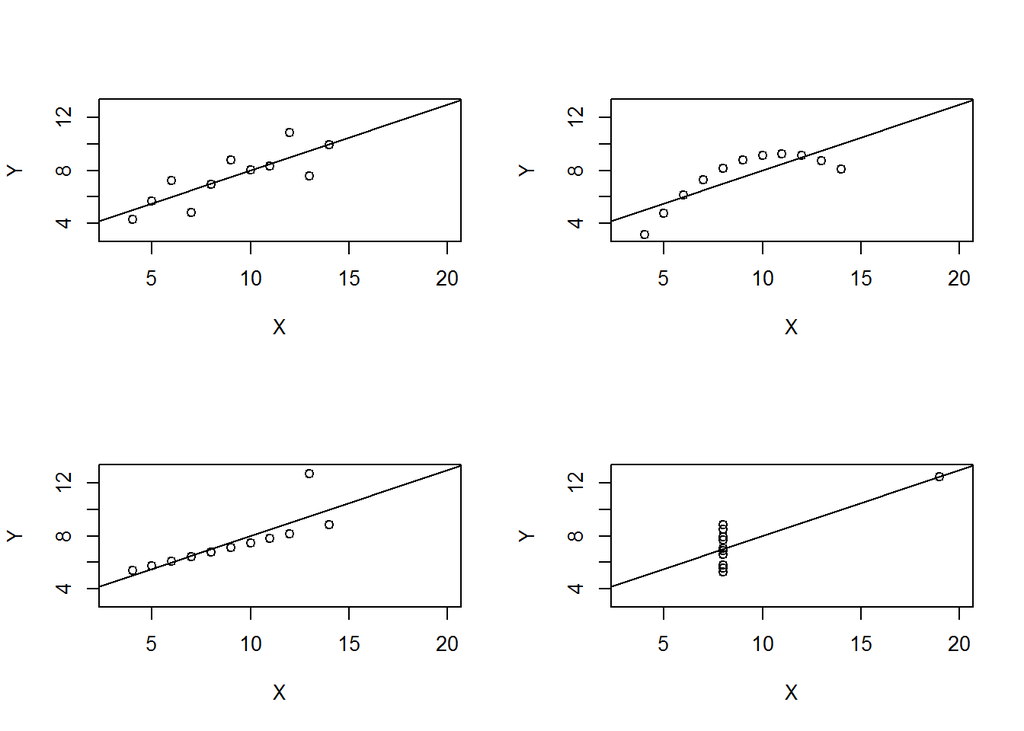

```r
attach(Anscombe)
par(mfrow = c(2,2))
plot(c(3,20), c(3,13), type="n", xlab = "X", ylab = "Y"); points(X,Y1); abline(lm(Y1~X))
plot(c(3,20), c(3,13), type="n", xlab = "X", ylab = "Y"); points(X,Y2); abline(lm(Y2~X))
plot(c(3,20), c(3,13), type="n", xlab = "X", ylab = "Y"); points(X,Y3); abline(lm(Y3~X))
plot(c(3,20), c(3,13), type="n", xlab = "X", ylab = "Y"); points(X4,Y4); abline(lm(Y4~X4))
```

系数都是3和0.5并且都显著。可是作图结果形状完全不一致2是曲线3有异常值4除了一个点以外都是同一个竖线上

```r
#1没有问题
par(mfrow = c(1,1))
#2是个曲线，加入平方拟合
X2<-X^2
#存放用平方拟合的系数
lm2.sol<-lm(Y2~X+X2)
summary(lm2.sol)
```

```
##
## Call:
## lm(formula = Y2 ~ X + X2)
##
## Residuals:
##       Min        1Q    Median        3Q       Max
## -0.001329 -0.001189 -0.000629  0.000874  0.002378
##
## Coefficients:
##              Estimate Std. Error t value Pr(>|t|)
## (Intercept) -6.00e+00   4.33e-03   -1385   <2e-16 ***
## X            2.78e+00   1.04e-03    2674   <2e-16 ***
## X2          -1.27e-01   5.71e-05   -2219   <2e-16 ***
## ---
## Signif. codes:  0 '***' 0.001 '**' 0.01 '*' 0.05 '.' 0.1 ' ' 1
##
## Residual standard error: 0.00167 on 8 degrees of freedom
## Multiple R-squared:     1,   Adjusted R-squared:     1
## F-statistic: 7.38e+06 on 2 and 8 DF,  p-value: <2e-16
```

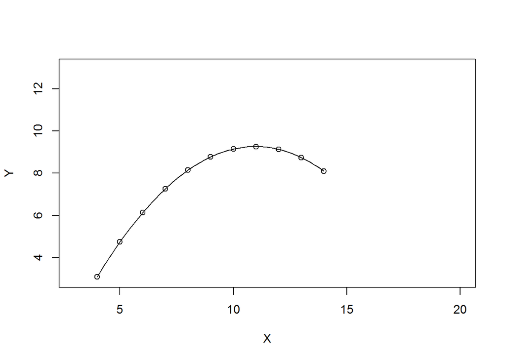

```r
#作图用x
x<-seq(min(X), max(X), by=0.1)
#作图用系数
b<-coef(lm2.sol)
y<-b[1]+b[2]*x+b[3]*x^2
plot(c(3,20), c(3,13), type="n", xlab = "X", ylab = "Y")
#plot原图
points(X,Y2)
lines(x,y)
```

```r
#3
#去掉第三个（异常值）
i<-1:11; Y31<-Y3[i!=3]; X3<-X[i!=3]
lm3.sol<-lm(Y31~X3)
summary(lm3.sol)
```

```
##
## Call:
## lm(formula = Y31 ~ X3)
##
## Residuals:
##       Min        1Q    Median        3Q       Max
## -0.006017 -0.001212 -0.001017 -0.000823  0.014069
##
## Coefficients:
##             Estimate Std. Error t value Pr(>|t|)
## (Intercept) 4.010628   0.005711     702   <2e-16 ***
## X3          0.345043   0.000626     551   <2e-16 ***
## ---
## Signif. codes:  0 '***' 0.001 '**' 0.01 '*' 0.05 '.' 0.1 ' ' 1
##
## Residual standard error: 0.00602 on 8 degrees of freedom
## Multiple R-squared:     1,   Adjusted R-squared:     1
## F-statistic: 3.04e+05 on 1 and 8 DF,  p-value: <2e-16
```

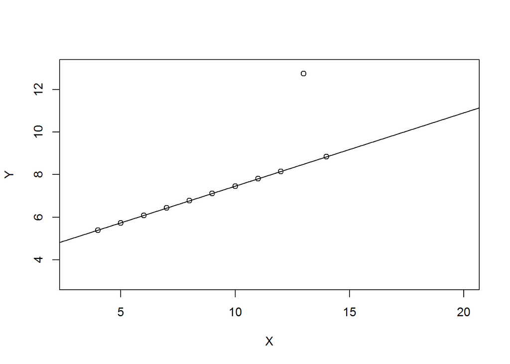

```r
plot(c(3,20), c(3,13), type="n", xlab = "X", ylab = "Y")
points(X,Y3)
abline(lm3.sol)
```

```r
detach(Anscombe)
```

## 1.3 异常值检测

1.diffits指标

$$DFFITS=\frac{\hat{y_i}-\hat{y_{i(i)}}}{s_(i)\sqrt{h_{ii}}}\sqrt{h_{ii}/(1-h_{ii})}$$

h是帽子矩阵，y尖=hy

```r
attach(Anscombe)
p<-1; n<-length(X);d<-dffits(lm(Y3~X, data=Anscombe))
cf<-1:n; cf[d>2*sqrt((p+1)/n)]
```

```
## [1] 3
```

```r
#取出1到n里面满足dffits大于2根号（（p+1）/n）
detach(Anscombe)
```

返回了异常值位置3

2.Cook’s distance

$$D_i=\frac{(\hat{\beta}-\hat{\beta}^{(-i)})^{T}(X^{T}X)(\hat{\beta}-\hat{\beta}^{(-i)})}{(1+p)s^{2}}$$

```r
Fit<-lm(Y3~X, data=Anscombe)
cooks.distance(Fit)
```

```
##        1        2        3        4        5        6        7        8
## 0.011831 0.002183 1.392828 0.005525 0.026072 0.300634 0.000480 0.033194
##        9       10       11
## 0.059650 0.000218 0.006752
```

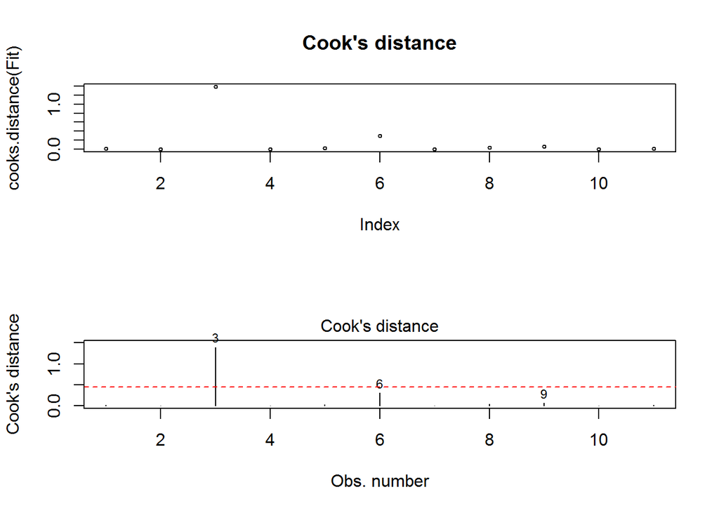

```r
par(mfrow=c(2,1))
#散点图
plot(cooks.distance(Fit),main="Cook's distance",cex=0.5)
#线图，红线表示警戒线
Np<-length(coefficients(Fit))-1#变量数
N<-length(fitted(Fit))
#红线算法
CutLevel<-4/(N-Np-1)
plot(Fit,which=4)
abline(CutLevel,0,lty=2,col="red")
```

summary

```r
#可以直接算dffit和cook，有问题的会带星号
influence.measures(lm(Y3~X, data=Anscombe))
```

```
## Influence measures of
##   lm(formula = Y3 ~ X, data = Anscombe) :
##
##       dfb.1_     dfb.X    dffit    cov.r   cook.d    hat inf
## 1  -4.64e-03 -4.43e-02  -0.1468 1.34e+00 0.011831 0.1000
## 2  -3.75e-02  1.88e-02  -0.0624 1.39e+00 0.002183 0.1000
## 3  -1.83e+02  2.69e+02 342.7851 7.36e-10 1.392828 0.2364   *
## 4  -3.31e-02 -2.66e-18  -0.0997 1.36e+00 0.005525 0.0909
## 5   4.92e-02 -1.17e-01  -0.2197 1.34e+00 0.026072 0.1273
## 6   4.90e-01 -6.67e-01  -0.7898 1.36e+00 0.300634 0.3182
## 7   2.60e-02 -2.01e-02   0.0292 1.53e+00 0.000480 0.1727
## 8   2.39e-01 -2.07e-01   0.2449 1.80e+00 0.033194 0.3182   *
## 9   1.38e-01 -2.32e-01  -0.3365 1.34e+00 0.059650 0.1727
## 10 -1.54e-02  1.05e-02  -0.0197 1.45e+00 0.000218 0.1273
## 11  1.04e-01 -8.62e-02   0.1098 1.64e+00 0.006752 0.2364
```

## 1.4 最大似然估计

The following function is called a likelihood function, denoted by LF($\beta_1$; $\beta_2$; $\sigma^{2}$)
$$LF(\beta_1,\beta_2,\sigma^{2})=f(Y_1,Y_2,\dots,Y_n|\beta_1+\beta_2X_i,\sigma^{2})=\frac{1}{\sigma^{n}(\sqrt{2\pi})^{n}}exp(\frac{1}{2}\sum \frac{(Y_i-\beta_1-\beta_2X_i)^{2}}{\sigma^{2}})$$
where $\beta_1$; $\beta_2$; $\sigma^{2}$ are not known. The method of maximum likelihood, as the name indicates, consists in estimating the unknown parameters in such a manner that the probability of observing the given Y’s is as high (or maximum) as possible. Therefore, we have to find the maximum of the function 6. For differentiation it is easier to express 6 in the log term as follows:
$$ln LF = -nln\sigma -\frac{n}{2}ln(2\pi)-\frac{1}{2}\sum \frac{(Y_i-\beta_1-\beta_2X_i)^{2}}{\sigma^{2}} \\
= -\frac{n}{2}ln\sigma^{2} -\frac{n}{2}ln(2\pi)-\frac{1}{2}\sum \frac{(Y_i-\beta_1-\beta_2X_i)^{2}}{\sigma^{2}}$$
Differentiating 7 partially with respect to $\beta_1$; $\beta_2$, and $\sigma^{2}$, we can obtain the ML estimators.

```
install.packages(maxLik)
```

```r
library("maxLik")
indfood<-read.csv(file="C:\\Users\\44180\\Documents\\R-in-SOE\\R\\R-class\\c9\\Indfood.csv")
#抽取数据
foodexp<-indfood[,1]
totalexp<-indfood[,2]
#OLS回归
lm_r <- lm(foodexp~totalexp)
summary(lm_r)
```

```
##
## Call:
## lm(formula = foodexp ~ totalexp)
##
## Residuals:
##     Min      1Q  Median      3Q     Max
## -153.77  -46.61    7.75   37.70  171.59
##
## Coefficients:
##             Estimate Std. Error t value Pr(>|t|)
## (Intercept)  94.2088    50.8563    1.85     0.07 .
## totalexp      0.4368     0.0783    5.58  8.5e-07 ***
## ---
## Signif. codes:  0 '***' 0.001 '**' 0.01 '*' 0.05 '.' 0.1 ' ' 1
##
## Residual standard error: 66.9 on 53 degrees of freedom
## Multiple R-squared:  0.37,   Adjusted R-squared:  0.358
## F-statistic: 31.1 on 1 and 53 DF,  p-value: 8.45e-07
```

```r
#最大似然估计
#对数似然函数
loglik=function (para){
N=length(foodexp)#样本量
e=foodexp-para[1]-para[2]*totalexp#残差项表达式，para是参数估计量
ll=-0.5*N*log(2*pi)-0.5*N*log(para[3]^2)-0.5*sum(e^2/para[3]^2)#对数似然函数，注意有个参数3
return(ll)
}
#需要1，log后的似然函数，初始值
mle1=maxLik(loglik,start=c(0.1,1,1))#3个参数，β1 β2，方差
coef(mle1)
```

```
## [1]  94.266   0.437 -65.601
```